# 2015-2 - Modelagem e Simulaçãoo Computacional

Alunos

06 de novembro de 2015

## Clima

Os dados meteorológicos são fornecidos pelo serviço sisalert.

### Estações

```r
station <- "5602a58b92c884831962ceea"
```

Os códigos das estações estão disponíveis no link abaixo em formato JSON(JavaScript Object Notation), no campo _id, ilustrado na Imagem 1:

http://dev.sisalert.com.br/apirest/api/v1/stations

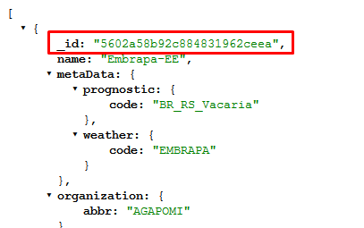

Imagem 1

### Dados metereológicos

```r
range <- "01-11-2014/01-01-2015"
```

Indica qual o intervalo usado para selecionar os dados metereológicos. A data inicial está localizada antes do / e a data final depois do /.

```r
datainicial <- "01-11-2014"
```

Data inicial

```r
datafinal <- "01-01-2015"
```

Data final

Com os dados de entrada fornecidos, é possivel montar a URL para solicitar os dados de clima

http://dev.sisalert.com.br/apirest/api/v1/data/station/model/5602a58b92c884831962ceea/range/01-11-2014/01-01-2015

### Algoritmo em R

Segue o algoritmo que transforma de JSON para Data.frame:

```r
library(RCurl)
library(rjson)
dataCurl <- getURLContent(urlclima, ssl.verifypeer = FALSE)
jsonWeather <- fromJSON(dataCurl)
weatherData <- do.call(rbind, lapply(jsonWeather, function(x) data.frame(x)))

head (weatherData)
```

```
##    date par rain srad tmax tmin
## 1 14154  25  0.0   12 12.9  7.4
## 2 14153  25  2.8   12 15.3  9.8
## 3 14152  25  0.0   12 14.1  9.4
## 4 14151  25  0.0   12 16.1  2.0
## 5 14150  25  1.0   12 14.1  5.9
## 6 14149  25  0.4   12 19.2 12.9
```

## Ajustando o modelo para três tipos de solo:

Após definido a bibliografia base, definiu-se três tipos de solo:

Solo arenoso, com teor de argila de 152 g kg-1;

Solo médio com teor de argila de 420 g kg-1;

Solo argiloso com teor de argila de 716 g kg-1;

Na tabela 1 abaixo ilustramos os parametros para cada tipo de solo:

#### Tabela 1-Tipos de solos e suas caracteristicas

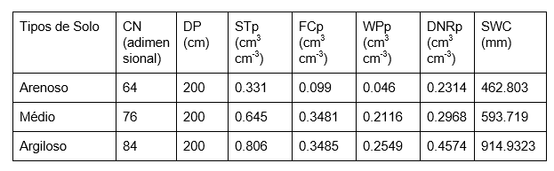

CN: número de curva, utilizado a tabela contida em (5);

DP: profundidade do perfil do solo, utilizado a tabela contida em (5);

STp: umidade do solo saturado;

FCp: umidade do solo na capacidade de campo;

WPp: umidade do solo no ponto de murcha permanente;

DNRp: percentual de drenagem diária;

SWC: lamina de água disponível no perfil de solo considerado (mm). Para calcular os valores de STp, FCp, WPp, DNRp e SWC se utilizou os parametros do modelo de Van Genuchten.

### Assim, os cálculos para cada tipo de solo são:

#### Para o solo arenoso:

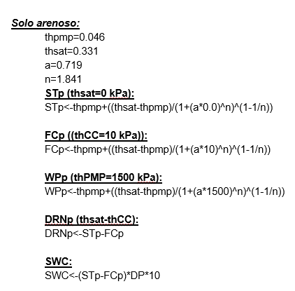

#### Para o solo médio:

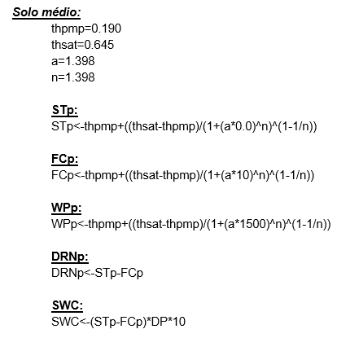

#### Para o solo argiloso:

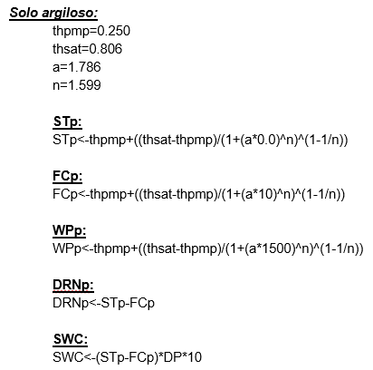